# 短期集中研修『Rデータ自由自在（入門編）』

三村喬生 (連絡先：kmimura[at]ism.ac.jp)

### 0. 受講のための準備

受講用のノートPCをご用意の上、**受講のための準備**をよく読み、以下の操作を完了させてください。エラーや不明な点が生じた場合は上記連絡先宛に電子メールでお問い合わせください。

- **【1】Rのインストール**
- **【2】RStudioのインストール**
- **【3】パッケージのインストール**
- **【4】動作確認**
- 【5】RStudioの表示設定のカスタム(適宜)

**ANOVAについて追記しました** 2023.12.20。

### 1. データ科学の基礎

- データ科学とは何か
- データ科学の倫理

資料1: データ科学の基礎

### 2. Rを始めよう

- R基礎知識
  - オブジェクトと関数
  - レポート作成
- データの読み書き
- データ操作
  - tidyverseパッケージによるテーブルデータの加工
  - データの縦型⇔横型変換
  - 行, 列方向のデータ加工
- データ可視化
  - ggplot2パッケージによる作図

資料2: R基礎知識・データの読み書き

資料3: データの操作・可視化

### 5. 確率論

- 確率とは何か
- 確率分布
- 確率変数

資料4: 確率論の基礎

### 6. 回帰モデル入門

- 最小二乗法
- 回帰モデルの基礎

### 7. 分散分析

- 分散分析の基礎

資料5: 回帰モデル・分散分析

### 8. 課題

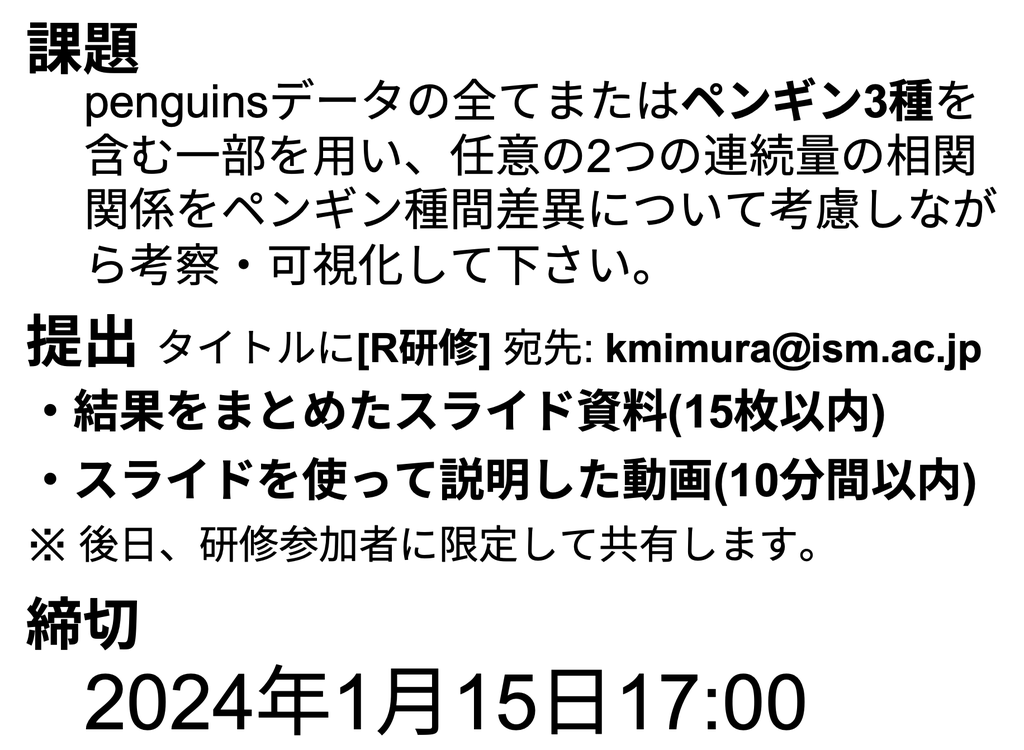

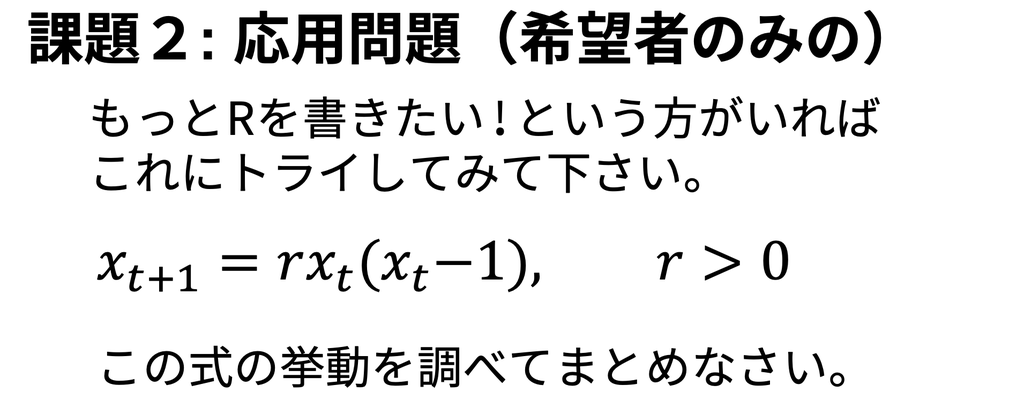

### 9. 参考文献

- 『改訂2版 RユーザのためのRStudio[実践]入門』 松村 優哉, 他 [[Amazon]](https://www.amazon.co.jp/dp/B095W5G8KB/)
- 『データ分析のためのデータ可視化入門』キーラン・ヒーリー [[Amazon]](https://www.amazon.co.jp/dp/4065164044/)
- 『確率と確率過程』 伏見 正則 [[Amazon]](https://www.amazon.co.jp/dp/4254295537)
- 『統計学入門 (基礎統計学Ⅰ)』 東京大学教養学部統計学教室 [[Amazon]](https://www.amazon.co.jp/dp/4130420658/)
- 『数値シミュレーションで読み解く統計のしくみ』 小杉 考司 他 [[Amazon]](https://www.amazon.co.jp/dp/4297136651)
- 『データ視覚化の人類史』 マイケル・フレンドリー 他 [[Amazon]](https://www.amazon.co.jp/dp/4791774191/)
- 『P値：その正しい理解と適用』柳川 堯 [[Amazon]](https://www.amazon.co.jp/dp/B07L888X33/)